# Week 3 Entropy Project

Sandesh Sadalge

Fri, Sept 12, 2014

**Dataset**

I put the data into my github directory to make things easier. Need to load a package before I can get it from github with this R-Markdown.

```r
fileLoc <- "https://raw.githubusercontent.com/spenglerss/MSDAFall2014/master/IS%20607%20Data%20Acquisition/P1_Entropy/entropy-test-file.csv"
dataset <- read.csv(text = getURL(fileLoc))
```

Obligatory summary information of the dataset. I think str() gives you a little more informative output for our purposes:

```r
head(dataset, n=5)
```

```
##   attr1 attr2 attr3 answer
## 1     0     A     2      0
## 2     0     A     2      0
## 3     0     A     2      0
## 4     0     A     1      0
## 5     0     A     1      0
```

```r
summary(dataset)
```

```
##      attr1     attr2       attr3           answer
##  Min.   :0.0   A:360   Min.   :0.000   Min.   :0.000
##  1st Qu.:0.0   B:340   1st Qu.:0.000   1st Qu.:0.000
##  Median :0.0   C:300   Median :1.000   Median :0.000
##  Mean   :0.4           Mean   :0.991   Mean   :0.424
##  3rd Qu.:1.0           3rd Qu.:2.000   3rd Qu.:1.000
##  Max.   :1.0           Max.   :2.000   Max.   :1.000
```

```r
str(dataset)
```

```
## 'data.frame':    1000 obs. of  4 variables:
##  $ attr1 : int  0 0 0 0 0 0 0 0 0 0 ...
##  $ attr2 : Factor w/ 3 levels "A","B","C": 1 1 1 1 1 1 1 1 1 1 ...
##  $ attr3 : int  2 2 2 1 1 0 1 0 2 0 ...
##  $ answer: int  0 0 0 0 0 0 1 0 0 0 ...
```

**A)** Create the **entropy()** function:

Here is my final function code. Explanations follow.

```r
entropy <- function (d)
{
  partitions <- table(d)                        # (1)
  partitions <- partitions / sum(partitions)    # (2)
  partitions <- partitions * log2(partitions)   # (3)
  entropy <- -sum(partitions)                   # (4)
}
```

**(1)** Determining categorical partitions and their frequencies:

Initially, the hard part for me was coming up with a way to determine a given vector’s categorical partitions and their frequencies.

My first thoughts started down the path of either trying to convert to factor or using *unique()* to get the distinct categorical values and perhaps then using a loop to figure out the frequency. I realized this was probably a very *‘un-R’* way to do it.

Fortunately, I came across *table()* which seemed to do exactly what I was looking for. The code: `partitions <- table(d)` gives you a table with the distinct values & respective frequencies of the input vector, d. As an example, in our dataset, `table(dataset$answer)` returns:

```
##
##   0   1
## 576 424
```

**(2)** Thanks to the fact that R is a vectorized language, `partitions <- partitions / sum(partitions)` determines the probability of each of the partitions (based on frequency counts).

Again, inr our example on `table(dataset$answer)`, when you do this, you get:

```
##
##     0     1
## 0.576 0.424
```

**(3)** Similarly, `partitions <- partitions * log2(partitions)` gives you the individual calculation within the summation notation of the Entropy equation, probability * log2(probability).

```
##
##       0       1
## -0.4584 -0.5249
```

*(4)* And lastly, we just take the negative sum of the terms: `entropy <- -sum(partitions)`

```
## [1] 0.9833
```

**B)** Create the **infogain()** function

Here’s the code:

```r
infogain <- function (d, a)
{
  if (all(d==a) == TRUE)                                # (1)
  {
    infogain <- 0
  } else
  {
    entropy.d <- entropy(d)                             # (2)

    x <- table(a, d)                                    # (3)
    y <- (x / rowSums(x))                               # (4)
    y <- y * ifelse(is.infinite(log2(y)),0,log2(y))     # (5)
    z <- rowSums(x) / sum(x)                            # (6)
    entropy.a <- sum(z * -1 * rowSums(y))               # (7)

    infogain <- entropy.d - entropy.a
  }
}
```

**(1)** `if (all(d==a) == TRUE)` This is one of those pieces of code that one puts in after you’ve started testing and you realize there’s a special case that needs to be taken care of. I explain this much more fully in note 3 in the next function creation, decide(). Basically, if the d and a vectors are the same, the infogain should be 0. You don’t ‘gain’ anything for the same partition, right?

**Note on explanations below:** I wish I could put together a video or something to explain how I’m calculating the probabilities and entropies using tables but I’ll try by best to explain using my limited R-Markdown abilities & some pictures I made in Excel:

Say you have a vector **d** with partitions *d.i* where *i = 1 … N* and another vector **a** with partitions *a.j* where *j = 1 … K*. Then, the infogain, **I(d,a) = E(d) - E(d,a)**.

You can get E(d) using the first function created which is what I did in **(2)** using `entropy(d)`.

As a reminder, you get the following entropy for `entropy(dataset$answer)`:

```
## [1] 0.9833
```

*But how do you get E(d,a)?*

I realized later that I could’ve created another function called `entropy(d,a)` to do this but I opted to put the code withint the infogain() function instead.

My solution uses *table()* again to create a 2 way table whose column names are *d.i* and row names are *a.j*. the value *(a.j,d.i)* equals the *frequency of the partitions **a.j & d.i***

Something like this:

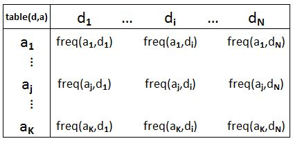

This is what line **(3)** does using `table(a, d)`

To be less abstract, for `d <- dataset$answer` and `a <- dataset$attr1` you get the following table:

```
##
##       0   1
##   0 347 253
##   1 229 171
```

**(4)** In how I’ve constructed this table, you will notice that the sum of the rows are the total frequecy of the partitions **a**.*j*:

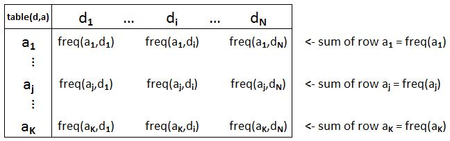

I use this fact to figure out the proabilities P(aj|di) (or is the notation P(di|aj)?) simply by dividing each element by the sum of the row. Or in my code, `(x / rowSums(x))`.

Continuing our example using `dataset$answer` and `dataset$attr1`, you get:

```
##
##          0      1
##   0 0.5783 0.4217
##   1 0.5725 0.4275
```

*Notice that the sum for each of the rows is 1.*

**(5)** Now that we have the probabilities, we just multiply by the log base 2 of each one respectively as the entropy equation states.

Here you’ll notice that I put a special case using `ifelse` for when log2() is infinity. One case where this will happen is if d and a are the same vector.

Using `dataset$answer` and `dataset$attr1` we get:

```
##
##           0       1
##   0 -0.4569 -0.5253
##   1 -0.4607 -0.5241
```

*Notice, after line (5), table x has the frequencies and table y has the component pieces of E(a.j)!!* Therefore, `rowSums(y)`, will now give you E(a.i). This fact will be useful in **(7)**.

**(6)** We need one last thing which is the weights for E(a.j). Since table x still holds the frequencies, the weights are simply `rowSums(x) / sum(x)` which I put into **z**.

**(7)*** What does `sum(z * -1 * rowSums(y))` do? Well, since `rowSums(y)` is the entropy for E(a.j) and z has the weights for a.j, multiplying the two, taking the negative of it and summing it up will give you the total entropy E(d,a).

The whole process looks like this:

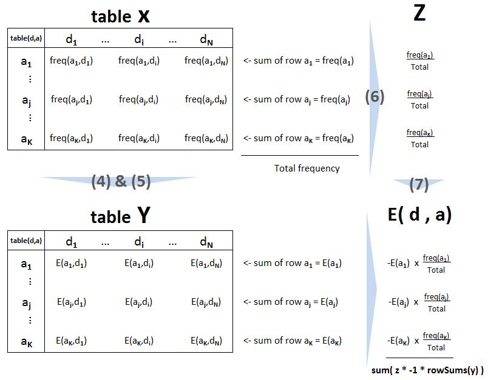

Examples for (6) & (7):

Entropies E(a.j) or `rowSums(y)`

```
##       0       1
## -0.9822 -0.9848
```

Weights in table **z**:

```
##   0   1
## 0.6 0.4
```

Above two are multiplied & added and negated to get to the final total for E(d,a):

```
## [1] 0.9832
```

Lastly, the Infogain is E(d) - E(d,a) which is:

```
## [1] 2.412e-05
```

Examples asked for in the assignment (apaprently R-Markdown rounds a little differently than the RStudio console):

`infogain(dataset$answer,dataset$attr1)` = 2.4116 × 10<sup>-5</sup>

`infogain(dataset$answer,dataset$attr2)` = 0.2599

`infogain(dataset$answer,dataset$attr3)` = 0.0024

**C)** Create the **decide()** function

Here’s the code:

```r
decide <- function(inputDF, col)
{
  x <- apply(inputDF,2,infogain,inputDF[,col])
  decide <- list(max=which.max(x), gains=x)
}
```

After hours of trying to figure out how to do this using *apply()*, *I finally got it!*

The explanation is pretty easy. You simply *apply()* the function *infogain()* to each of the columns in the inputDF against the reference column. I know the statement is really simple but boy did it take me forever to finally figure out why and how to get it right!

The *apply()* outputs a vector assigned, to x, which allows you to easily lookup the maximum value using *which.max()*.

It’s a simple thing then, to return a list with the maximum infogain column number and the list of infogains by column as the assignment asks for.

```
Oh, and last note:

It was after writing this function that I had to go back to the original infogain() function I wrote and put in the special case for checking if the vectors are the same. The reason is that since I iterate through all the columns, I will always try to do the infogain for the reference vector and itself.  Infogain in this case should be 0. (You shouldn't 'gain' anything if you subset back on the same criteria.)

What actually happened in my original infogain() function was that E(d) gave a valid number but when I tried to do entropy(d,d) it rerutned 0.  Why?  because I put a catch for the infinities associated with log2(0) which made E(d,a) = 0 . Therefore, the infogain = E(d) - E(d,a) was reverting to simply E(d) which was wrong.

After puzzling through it, there were two solutions I could see: Either I do not account for the infinities and allow the infogain() function to return NaN or I could put a test in the very begining of the infogain() function to check if the vectors are exactly the same.  I chose the latter.
```

Here is the original function I wrote and glad I didn’t submit:

```
decide2 <- function(inputDF, col)
{
  decideDF <- data.frame(colnames=colnames(inputDF))
  n <- length(decideDF$colnames)
  infogain.values <- rep(0, n)
  for (i in 1:n)
  {
    infogain.values[i] <- infogain(inputDF[,col], inputDF[,i])
  }

  decideDF <- data.frame(colnames=decideDF$colnames,infogain=infogain.values)

  decide2 <- list(max=which.max(infogain.values), gains=decideDF)
}
```

### Lastly, let’s see if the outputs match the expected ones:

```r
(entropy(dataset$answer))
```

```
## [1] 0.9833
```

```r
(infogain(dataset$answer, dataset$attr1))
```

```
## [1] 2.412e-05
```

```r
(infogain(dataset$answer, dataset$attr2))
```

```
## [1] 0.2599
```

```r
(infogain(dataset$answer, dataset$attr3))
```

```
## [1] 0.002433
```

```r
(decide(dataset,4))
```

```
## $max
## attr2
##     2
##
## $gains
##     attr1     attr2     attr3    answer
## 2.412e-05 2.599e-01 2.433e-03 0.000e+00
```